# Module 2- Pulse of the City

Blair Wong

2023-01-27

## Background

Continuing the analysis with Craigslist data provided by [BARI](https://dataverse.harvard.edu/dataset.xhtml?persistentId=doi:10.7910/DVN/52WSPT), we will dive further into the price and square footage data. In addition, we will explore the distribution of listings across neighborhoods on Craigslist as well as the listing dates. Finally, we will look at the data regarding pets and investigate how many listings allow cats and dogs.

For pricing and square footage data, I wanted to gain a fuller understanding of the overall rental prices in Boston, as well as the sizes of listings. The price and square footage data also might provide insightful information on the dynamics between renters and landlords/brokers in the city.

In terms of neighborhood distribution, I wanted to better understand the turnover across various neighborhoods, as well as which neighborhoods might skew towards using Craigslist versus other sites such as Zillow or Apartments.com.

Supplementing the neighborhood distribution, I also wanted to investigate the turnover in terms of listing dates and how often people were moving in and out during 2020 and 2021. This could help paint a picture of the effects of the COVID-19 pandemic on Boston’s rental scene.

Lastly, with regards to pets, I wanted a better understanding of how many listings allow dogs and cats since these requirements can make it more difficult for pet owners to move.

Taken together, these pieces of data can help us paint a fuller picture of the rental scene in Boston.

As with the previous analysis in [“Tell A Data Story”](https://sppua5262.wordpress.com/2023/01/23/tell-a-data-story-craigslist-2/), I will focus on listings that are located in Greater Boston.

```r
craigslist_listings<-read.csv('../dataverse_files/CRAIGSLIST.Listings.csv')

greater_boston_cities<- list('Allston','Back Bay','Bay Village','Beacon Hill','Brighton','Charlestown','Chinatown','Dorchester','Downtown','East Boston','Fenway-Kenmore','Hyde Park','Jamaica Plain','Mattapan','Mission Hill','North End','Roslindale','Roxbury','South Boston','South End','West End','West Roxbury', 'Wharf District','Cambridge','Somerville','Everett','Chelsea','Revere','Quincy','Watertown','Brookline')

craigslist_listings_subset<-craigslist_listings %>% filter(LOCATION!='',LOCATION %in% greater_boston_cities) %>% select(LISTING_ID,LISTING_YEAR,LISTING_MONTH,LOCATION,AREA_SQFT,PRICE)

count(craigslist_listings_subset)
```

```
##       n
## 1 46436
```

## Price & Square Footage

#### Methods

To better understand the prices & square footage for the listings, we can generate a summary table to describe the basic statistical values of the data. Using the `modelsummary` package, we can see the number of unique values, percentage of missing values, mean, standard deviation, minimum, median, and maximum. The table also provides a histogram to show the distribution of the values as well.

```r
datasummary_skim(craigslist_listings_subset[c('PRICE','AREA_SQFT')])
```

Unique (#)

Missing (%)

Mean

SD

Min

Median

Max

PRICE

1789

0

2391.7

846.9

70.0

2250.0

7000.0

[figure not shown]

AREA_SQFT

1027

65

1179.2

6680.8

0.0

900.0

710940.0

[figure not shown]

Given that the lowest rental price is $70, and the lowest square footage is 0 square ft, we can conclude that there is some data that is skewing the results and should be excluded. Also, for `AREA_SQFT`, it appears as though 65% of listings are missing square footage information.

To determine what would be a reasonable cut off for price, we can filter to see how many listings are above a certain price. Since there is a significant jump from number of listings below $400 & $500, we can treat listings under $400 as outliers and exclude them.

```r
count(filter(craigslist_listings_subset, PRICE < 400))
```

```
##    n
## 1 17
```

```r
count(filter(craigslist_listings_subset, PRICE < 500))
```

```
##    n
## 1 62
```

```r
craigslist_listings_subset <- filter(craigslist_listings_subset, PRICE > 400)
```

Looking at the square footage more closely, we can see that the minimum is 0.0 square ft, and the maximum is 710940.0 square ft, both of which are not possible values. Similar to price, we can filter out the outliers. A quick glance at the histogram in the table shows that only a few values are significantly high, which means we can eliminate the maximum value. To determine where the cut off is, I compared the number of listings above 2,000, 3,000, and 4,000 square feet. Since there is a major jump between 2,000 square feet and 3,000 square feet, we can use 3,000 as the maximum cut off. For the minimum, I ensured that the listings had above 100 square footage. A new summary table is created below.

```r
count(filter(craigslist_listings_subset, AREA_SQFT > 4000))
```

```
##     n
## 1 149
```

```r
count(filter(craigslist_listings_subset, AREA_SQFT > 3000))
```

```
##     n
## 1 155
```

```r
count(filter(craigslist_listings_subset, AREA_SQFT > 2000))
```

```
##     n
## 1 327
```

```r
craigslist_listings_subset <- filter(craigslist_listings_subset, AREA_SQFT < 3000)
craigslist_listings_subset <- filter(craigslist_listings_subset, AREA_SQFT > 100)

datasummary_skim(craigslist_listings_subset[c('PRICE', 'AREA_SQFT')])
```

Unique (#)

Missing (%)

Mean

SD

Min

Median

Max

PRICE

1045

0

2487.4

801.7

650.0

2375.0

7000.0

AREA_SQFT

1002

0

935.1

371.8

105.0

900.0

2994.0

[figure not shown]

#### Analysis

Looking at the initial summary table for price and square footage, there are some values that do not make sense. First, the lowest price for rent is $70, which does not seem reasonable for a listing. Since there are only 17 listings below $400 and there are 62 listings below $500, it seems as though anything below $400 can be considered an outlier. For square footage, a similar process was undertaken to eliminate any listings that were above 3,000 square feet. The lower cut off for square footage is 100 square feet, which is about the size of a parking space. Although 100 square feet is unreasonable for an entire apartment, some of the listings may be for just one bedroom, which means that although small, 100 square feet is possible. By enforcing a minimum value, the NA values for square footage were also eliminated.

Comparing the two summary tables, it appears as though the mean and median prices for rent went up slightly (from $2391.70 to $2487.40 and $2250 to $2375 respectively). This makes sense given that we removed the values lower than $400. For square footage, only the mean changed from 1,179.2 square feet to 935.1 square feet, and the median remained at 900 square feet. This is reasonable since we removed the highest values which were significantly skewing the mean. Also, since we are using the same dataset, but eliminating the lowest square footage, the minimum rent has also increased to $650.

## Neighborhood Distribution

#### Methods

To see the data on a neighborhood level, I created a table containing the frequencies of each neighborhood by using the `formattable` package and sorted it by the most frequent to least frequent.

```r
location_df <- as.data.frame(table(craigslist_listings_subset$LOCATION))
location_df_sorted<-location_df[order(location_df$Freq, decreasing = TRUE),]
colnames(location_df_sorted)<-c("Neighborhood", "Frequency")
formattable(location_df_sorted, format="html")
```

|  | Neighborhood | Frequency |
| --- | --- | --- |
| 5 | Brighton | 1757 |
| 7 | Cambridge | 1597 |
| 25 | Somerville | 1297 |
| 17 | Jamaica Plain | 1199 |
| 21 | Quincy | 951 |
| 9 | Chelsea | 929 |
| 1 | Allston | 831 |
| 6 | Brookline | 816 |
| 26 | South Boston | 813 |
| 11 | Dorchester | 758 |
| 13 | East Boston | 715 |
| 27 | South End | 670 |
| 28 | Watertown | 561 |
| 2 | Back Bay | 494 |
| 4 | Beacon Hill | 407 |
| 22 | Revere | 329 |
| 24 | Roxbury | 328 |
| 8 | Charlestown | 318 |
| 23 | Roslindale | 242 |
| 19 | Mission Hill | 212 |
| 14 | Everett | 208 |
| 20 | North End | 198 |
| 30 | West Roxbury | 114 |
| 16 | Hyde Park | 78 |
| 12 | Downtown | 70 |
| 18 | Mattapan | 28 |
| 10 | Chinatown | 26 |
| 29 | West End | 13 |
| 3 | Bay Village | 12 |
| 15 | Fenway-Kenmore | 1 |

A more effective way to view the data is through a bar graph as seen below.

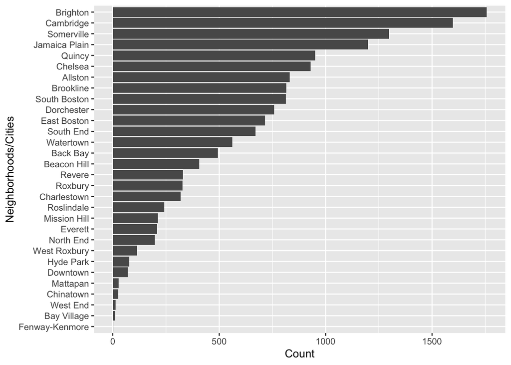

```r
base<-ggplot(craigslist_listings_subset, aes(x=reorder(LOCATION, LOCATION, length)))
base + geom_bar() + xlab("Neighborhoods/Cities") + ylab("Count") + coord_flip()
```

#### Analysis

The listings that are represented in the bar graph are the ones who were filtered according to the list of cities and neighborhoods in the Greater Boston area. Most of the listings were in Brighton (1,757), Cambridge (1,597), and Somerville (1,297). At the opposite end, there were only 13 listings for the West End, 12 for Bay Village, and 1 for Fenway-Kenmore.

#### Interpretation & Implications

There could be multiple reasons for why some neighborhoods would have more listings than others:

- Some neighborhoods had significantly more turnover during 2020 and 2021. In places such as Cambridge, people may have had enough economic security to pack up and move during the pandemic, leaving more availability.
- The people who use Craigslist to show rental listings may be targeting a specific demographic such as recent college graduates who are more likely to use Craigslist to find apartments near where they went to school or already have social networks.
- There may be fewer rentals in certain cities/neighborhoods where people are more likely to buy.
- Craigslist is not the only place to find rental properties. This means that for some of the neighborhoods with less listings, they may be on other sites such as Zillow or Facebook Marketplace. Perhaps in some more tight-knit communities, people market listings through word of mouth. This ultimately means that Craigslist on its own may not be the most accurate view of Boston’s rental market.

## Listing Dates

#### Methods

Similar to neighborhood distribution, I also created a table to display how many listings there were per month. To do this, I updated the `LISTING_MONTH` variable from a character type to a factor. This enabled me to then order the months chronologically rather than alphabetically.

```r
craigslist_listings_subset<-craigslist_listings_subset %>% mutate(LISTING_MONTH = factor(LISTING_MONTH, levels = c("January", "February", "March", "April", "May", "June", "July", "August", "September", "October", "November", "December")))
per_month_df <- as.data.frame(table(craigslist_listings_subset$LISTING_MONTH))
per_month_df_sorted<-per_month_df[order(per_month_df$Var1),]
colnames(per_month_df_sorted)<-c("Month", "Frequency")
formattable(per_month_df_sorted, format="html")
```

| Month | Frequency |
| --- | --- |
| January | 741 |
| February | 901 |
| March | 1094 |
| April | 1473 |
| May | 1626 |
| June | 1759 |
| July | 1757 |
| August | 1605 |
| September | 1919 |
| October | 1151 |
| November | 974 |
| December | 972 |

Another way to view this data is through a bar graph as seen below. This bar graph also shows how many listings were in each year.

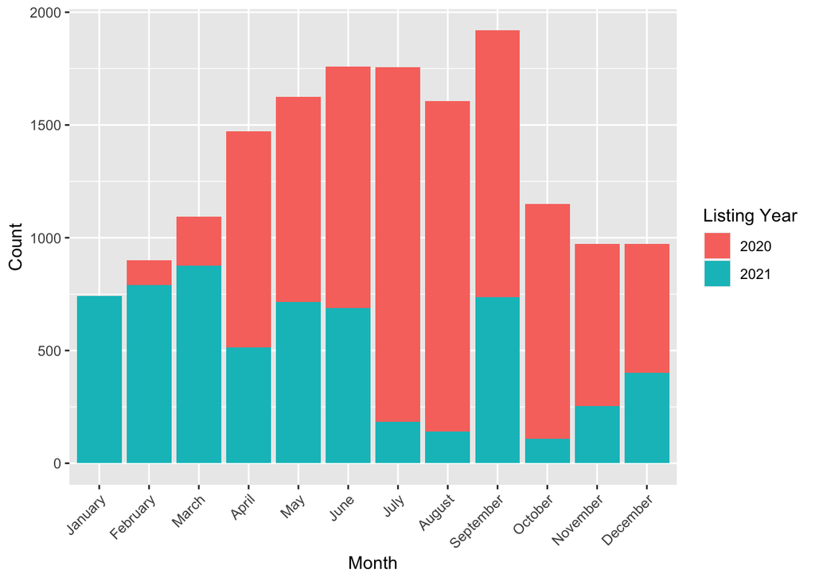

```r
base<-ggplot(craigslist_listings_subset, aes(x=LISTING_MONTH))
base + geom_bar(aes(fill=as.factor(LISTING_YEAR))) + theme(axis.text.x = element_text(angle = 45, vjust = 1, hjust = 1)) + labs(fill = "Listing Year") + xlab("Month") + ylab("Count")
```

#### Interpretation & Implications

When the COVID-19 pandemic hit in March 2020, there were not a lot of listings because people were likely quarantining and staying put. However, in April, listings picked back up as the listings originally intended for March were now posted. Then, in July and August of 2020, there was an influx of listings most likely due to people leaving the city because of the pandemic. In September, numbers were more “normal” most likely due to the number of students moving back to the City. The 2021 numbers show that less people moved in July, August, and the fall months (outside of September).

## Pets

#### Methods

Lastly, we can also see how many listings allow pets. I created a table for the `ALLOWS_DOGS` variable and for the `ALLOWS_CATS` variable. I also calculated and appended the percentage by dividing the frequency by the total frequency and multiplying by 100. Similar to neighborhood distribution and listing dates, I used the `formattable` package to create the tables.

```r
allows_dogs_df<-as.data.frame(table(craigslist_listings$ALLOWS_DOGS))
colnames(allows_dogs_df)<-c("AllowsDogs", "Frequency")
allows_dogs_df <- allows_dogs_df %>% mutate("Percentage (%)" = Frequency/sum(Frequency)*100)

formattable(allows_dogs_df, format="html")
```

| AllowsDogs | Frequency | Percentage (%) |
| --- | --- | --- |
| 0 | 131022 | 64.58517 |
| 1 | 71845 | 35.41483 |

```r
allows_cats_df<-as.data.frame(table(craigslist_listings$ALLOWS_CATS))
colnames(allows_cats_df)<-c("AllowsCats", "Frequency")
allows_cats_df <- allows_cats_df %>% mutate("Percentage (%)" = Frequency/sum(Frequency)*100)

formattable(allows_cats_df, format="html")
```

| AllowsCats | Frequency | Percentage (%) |
| --- | --- | --- |
| 0 | 89638 | 44.1856 |
| 1 | 113229 | 55.8144 |

To view the data graphically, I used the values above to make a pie chart for cats and dogs.

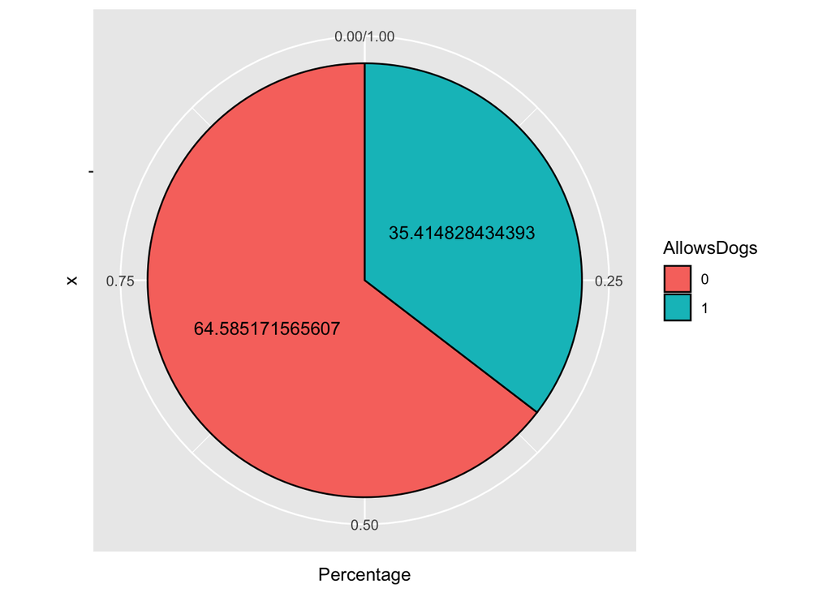

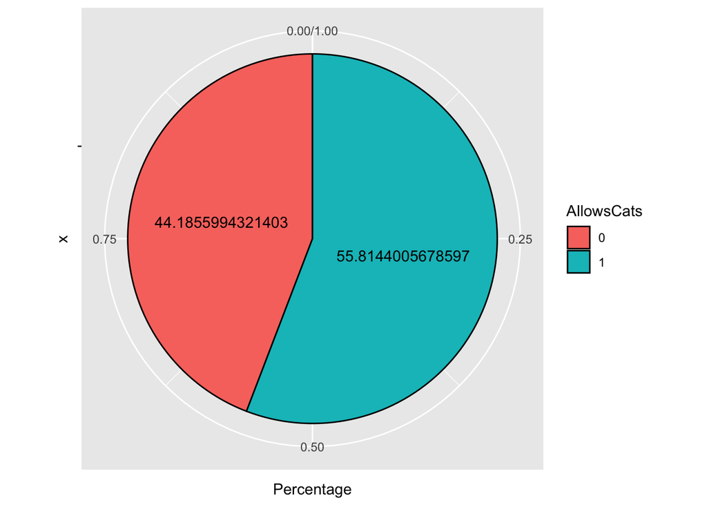

#### Analysis

Thirty-five percent of listings allow dogs, which means that 65% of listings do not. For cats, more listings allow cats (56%), than those who do not (44%).

#### Interpretation & Implications

Since more listings allow cats, this means that it is easier to move with a cat than with a dog. However, brokers and landlords may write in their listing that they do not allow cats or dogs, but tenants may be able to negotiate with the landlords who may allow pets anyway. Also, there are some tenants who move in without a pet and then negotiate with the landlord after moving in. This means that for some listings, the “no cats” or “no dogs” rule may be flexible.